# Untitled

suyeon

2019 6 10

## R Markdown

```r
library(ggplot2)
library(dplyr)
library(gridExtra)
```

1. mpg 데이터의 cty(도시 연비)와 hwy(고속도로 연비) 간에 어떤 관계가 있는지 알아보려고 합니다. #x축은 cty, y축은 hwy로 된 산점도를 만들어 보세요.

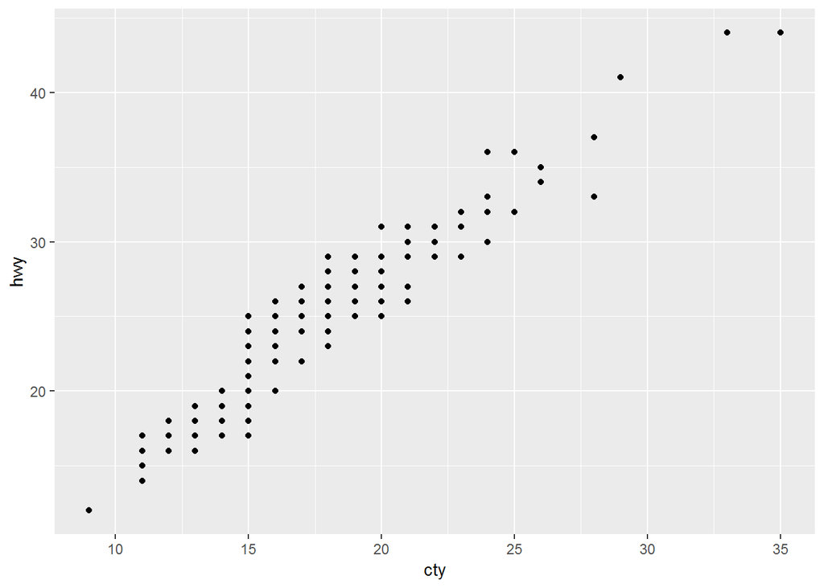

```r
ggplot(mpg, aes(x=cty, y=hwy, group=1)) + geom_point()
```

2. 미국 지역별 인구통계 정보를 담은 ggplot2 패키지의 midwest 데이터를 이용해서 전체 인구와 아시아인 인구 간에 #어떤 관계가 있는지 알아보려고 합니다. x축은 poptotal(전체 인구), y축은 popasian(아시아인 인구)으로 된 산점도를 만들어 보세요. #전체 인구는 50만 명 이하, 아시아인 인구는 1만 명 이하인 지역만 산점도에 표시되게 설정하세요.

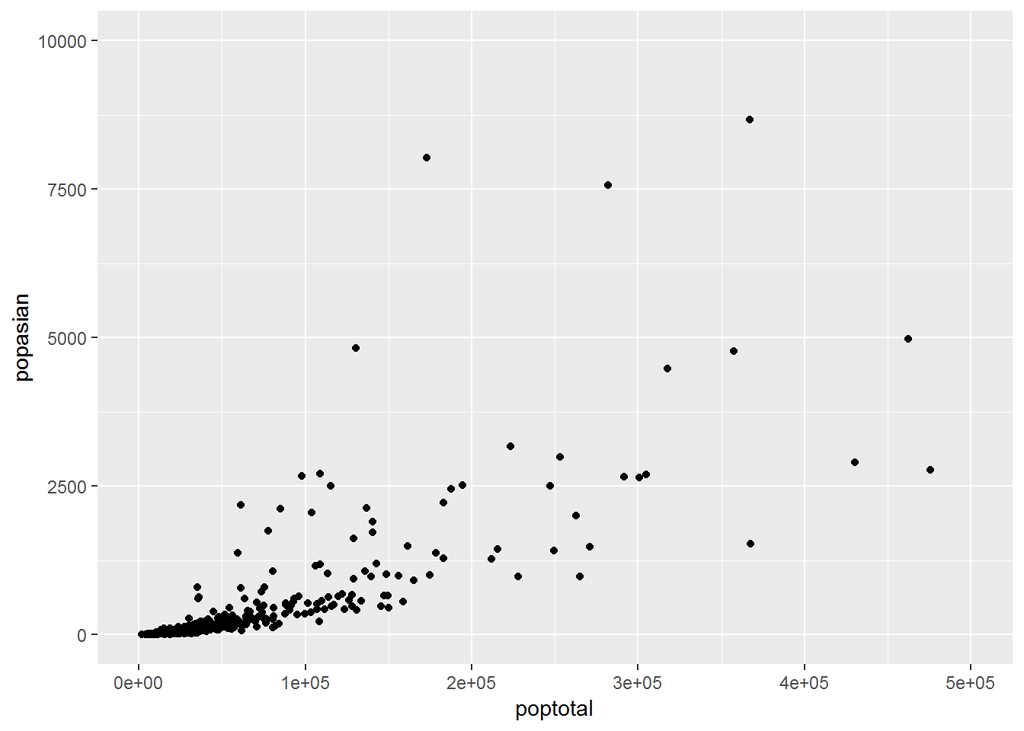

```r
ggplot(midwest, aes(x=poptotal, y=popasian)) + geom_point() + xlim(0,500000) + ylim(0,10000)
```

```r
suv <- mpg %>%
  filter(class == "suv") %>%
  group_by(manufacturer) %>%
  summarise(mean.cty = mean(hwy)) %>%
  arrange(desc(mean.cty)) %>%
  head(5)
suv
```

```
## # A tibble: 5 x 2
##   manufacturer mean.cty
##   <chr>           <dbl>
## 1 subaru           25
## 2 toyota           18.2
## 3 mercury          18
## 4 nissan           18
## 5 ford             17.8
```

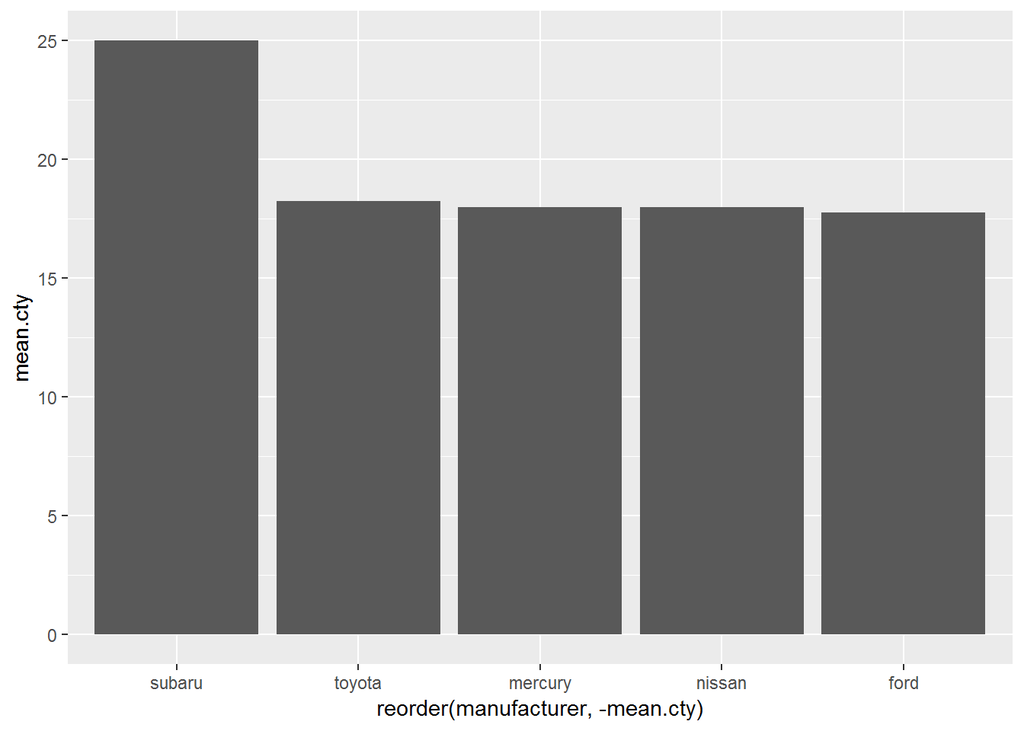

```r
ggplot(suv, aes(x=reorder(manufacturer, -mean.cty), y=mean.cty)) + geom_col()
```

4. 자동차 중에서 어떤 class(자동차 종류)가 가장 많은지 알아보려고 합니다. 자동차 종류별 빈도를 표현한 막대 그래프를 만들어 보세요.

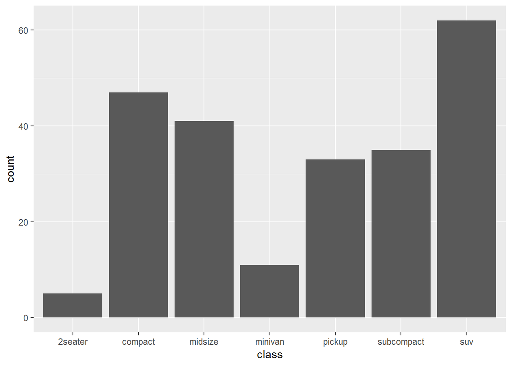

```r
ggplot(mpg, aes(x=class)) + geom_bar()
```

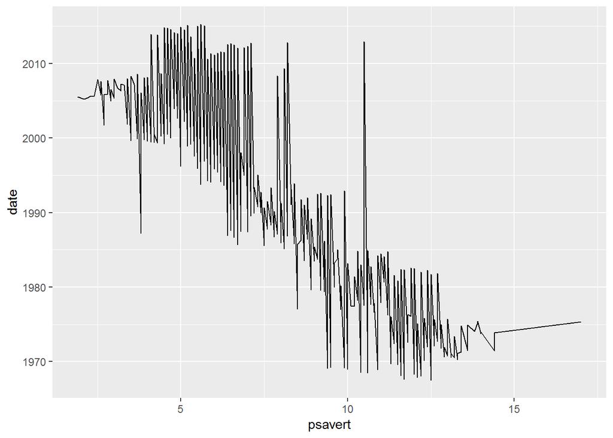

```r
ggplot(economics, aes(x=psavert, y=date)) + geom_line()
```

6. class(자동차 종류)가 “compact”, “subcompact”, “suv”인 자동차의 cty(도시 연비)가 어떻게 다른지 비교해보려고 합니다. #세 차종의 cty를 나타낸 상자 그림을 만들어보세요.

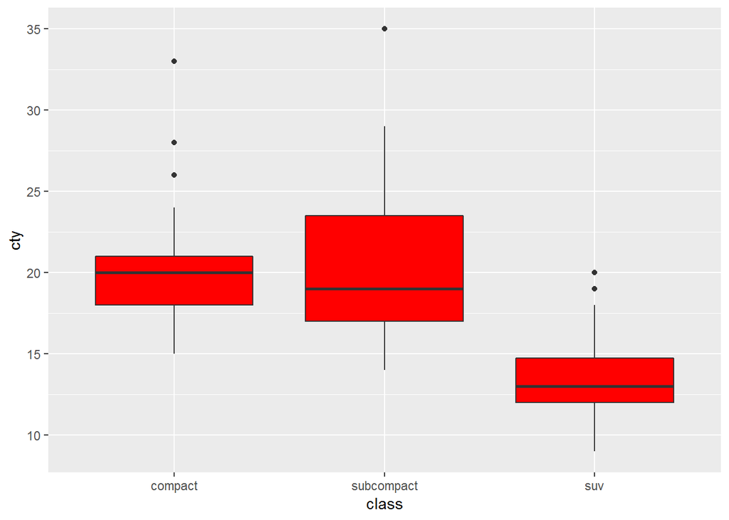

```r
class <- filter(mpg, class == "compact" | class == "subcompact" | class == "suv")
ggplot(class, aes(x=class, y=cty)) + geom_boxplot(fill="red")
```

7. Diamonds 데이터 셋을 이용하여 다음 문제를 해결하세요. 7-1. cut의 돗수를 보여주는 그래프를 작성하세요.

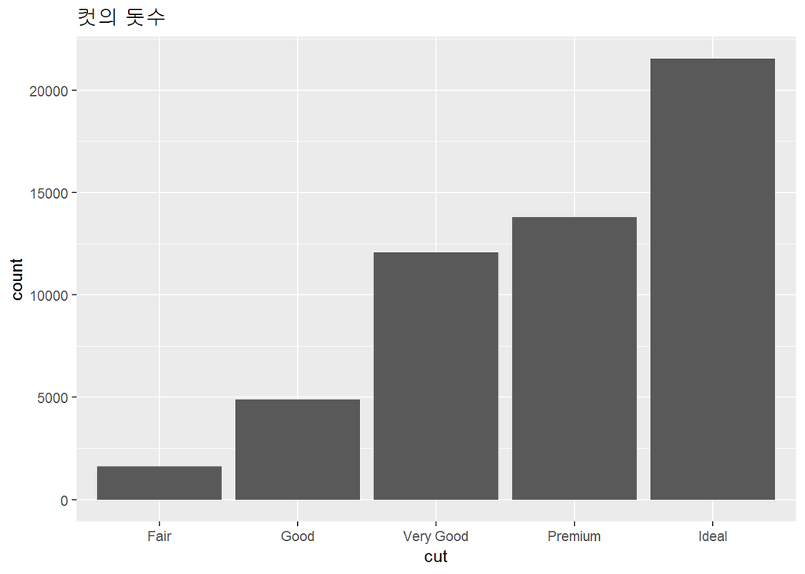

```r
ggplot(diamonds, aes(x=cut), fill="blue") + geom_bar() + ggtitle("컷의 돗수")
```

7-2. cut에 따른 가격의 변화를 보여주는 그래프를 작성하세요.

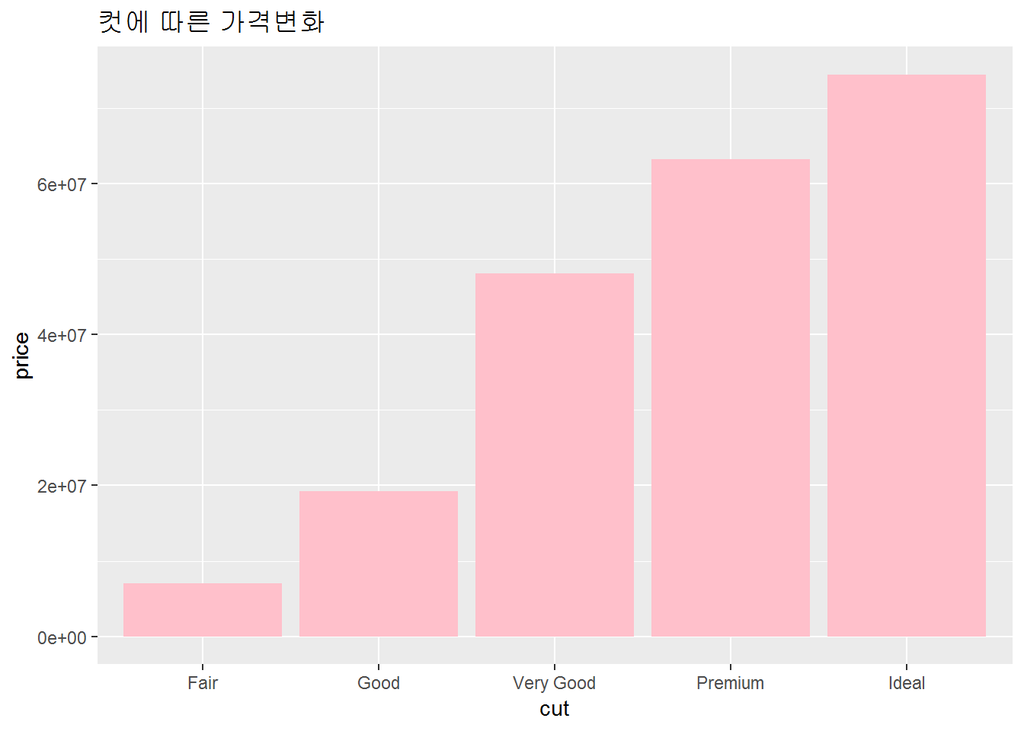

```r
ggplot(data=diamonds, aes(cut, price)) + geom_bar(stat='identity', fill="pink") + ggtitle("컷에 따른 가격변화")
```

7-3. cut과 color에 따른 가격의 변화를 보여주는 그래프를 작성하세요.

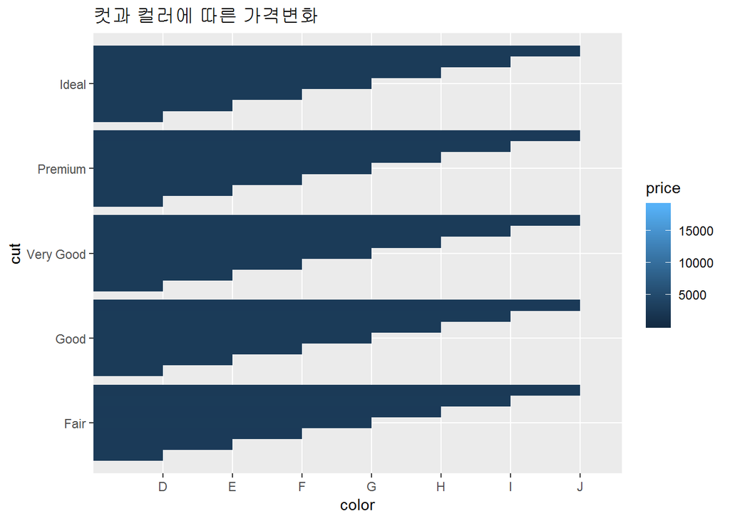

```r
ggplot(diamonds, aes(cut, color, fill=price)) +
  geom_bar(stat='identity', position = 'dodge') + coord_flip() + ggtitle("컷과 컬러에 따른 가격변화")
```